# R4DS_3.6-3.10

```r
# left
ggplot(data = mpg) +
  geom_point(mapping = aes(x = displ, y = hwy))

# right
ggplot(data = mpg) +
  geom_smooth(mapping = aes(x = displ, y = hwy))
```

[output not shown]

Keeping in mind how aesthetics initialized in the ggplot object will pass as default aesthetics to the following **geom** objects, we can very simply layer multiple geoms.

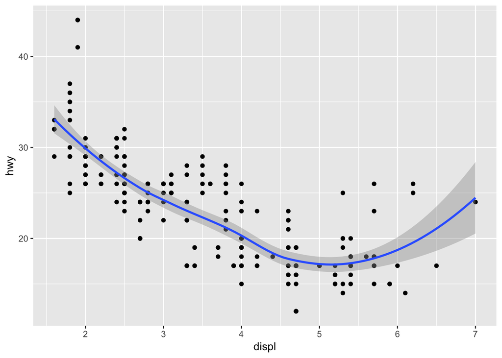

```r
ggplot(data = mpg, aes(x = displ, y = hwy)) +
  geom_point() +
  geom_smooth()
```

*Small tangent:*  
Be careful layering too many geoms because it can distract or take away from the point you are trying to convey to your audience. Simpler and fewer dimensions is almost always better with plots because your message becomes even more obvious. Instead of trying to make 3 points in 1 plot, try making 3 plots each convying 1 of those points.

Every geom function in ggplot2 takes a `mapping` argument. However, not every aesthetic works with every geom. You could set the shape of a point, but you couldn’t set the “shape” of a line. On the other hand, you *could* set the linetype of a line. `geom_smooth()` will draw a different line, with a different linetype, for each unique value of the variable that you map to linetype (can also be set with the `grouping` aesthetic). Make sure to make use of the `?geom_....()` to look at the docs that explain which aesthetics can be used with which **geom** objects.

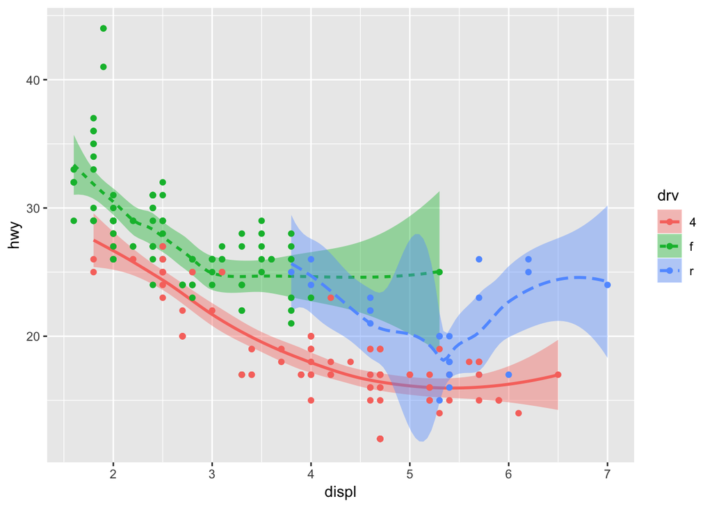

```r
ggplot(data = mpg, aes(x = displ, y = hwy)) +
  geom_smooth(mapping = aes(linetype = drv, color = drv, fill = drv)) +
  geom_point(mapping = aes(color = drv)) # Fill or linetype won't do anything here but you could set a shape aesthetic for geom_point()
```

You can also specify different `data` for each layer. Here, our smooth line displays just a subset of the `mpg` dataset, the subcompact cars. The local data argument in `geom_smooth()` overrides the global data argument in `ggplot()` for that layer only.

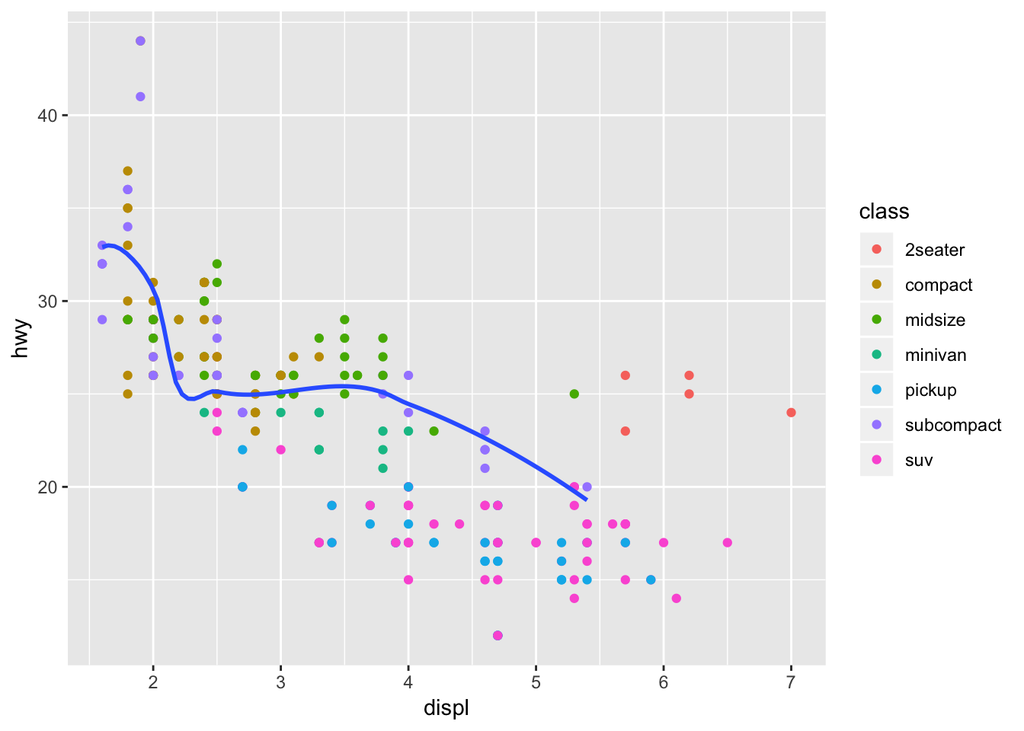

```r
ggplot(data = mpg, mapping = aes(x = displ, y = hwy)) +
  geom_point(mapping = aes(color = class)) +
  geom_smooth(data = filter(mpg, class == "subcompact"), se = FALSE)
```

### Practice Exercises

1. Will these two graphs look different? Why/why not?

   ```r
   ggplot(data = mpg, mapping = aes(x = displ, y = hwy)) +
     geom_point() +
     geom_smooth()

   ggplot() +
     geom_point(data = mpg, mapping = aes(x = displ, y = hwy)) +
     geom_smooth(data = mpg, mapping = aes(x = displ, y = hwy))
   ```

2. Recreate the R code necessary to generate the following graphs.

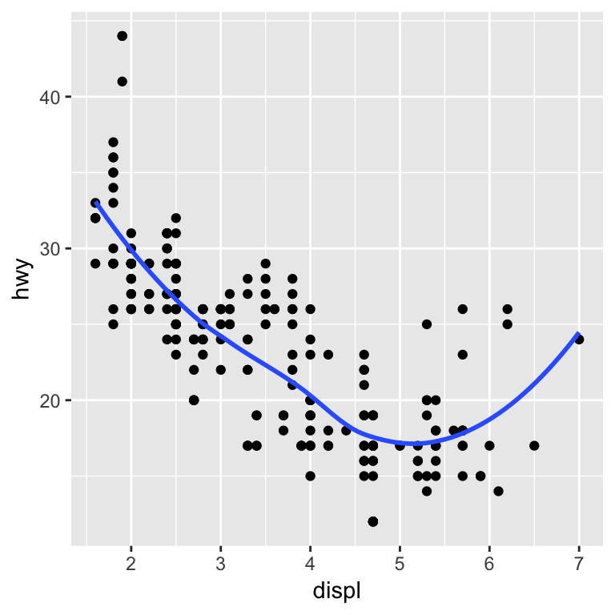

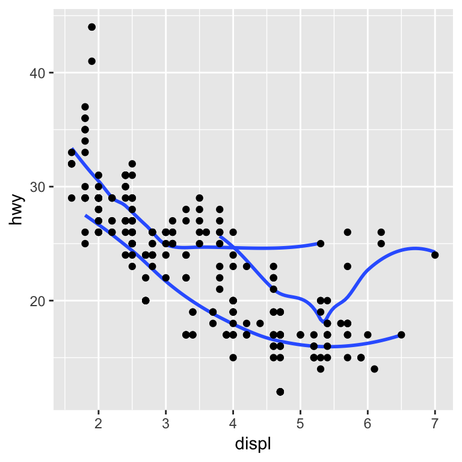

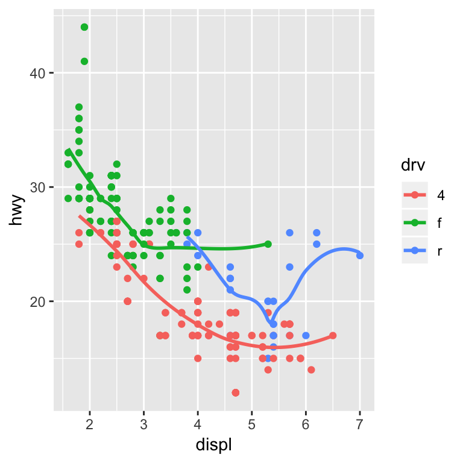

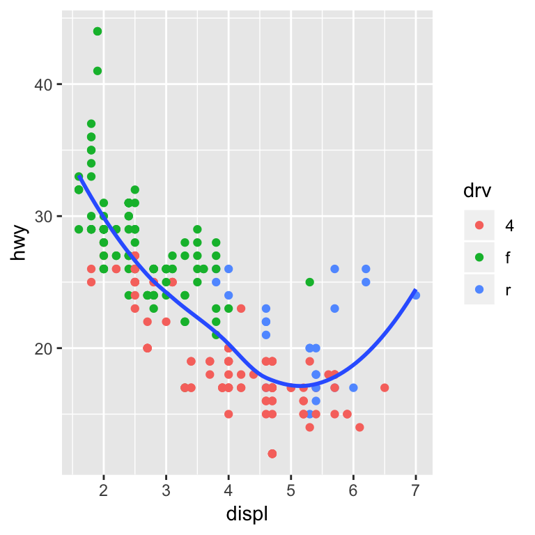

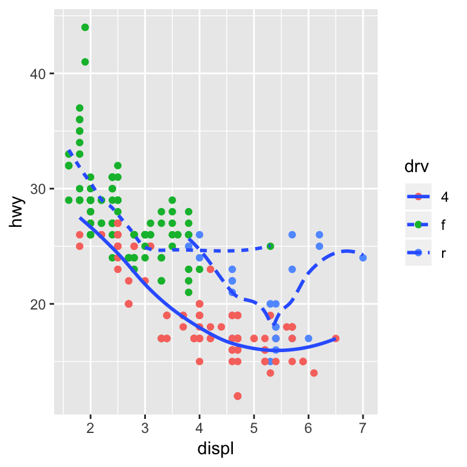

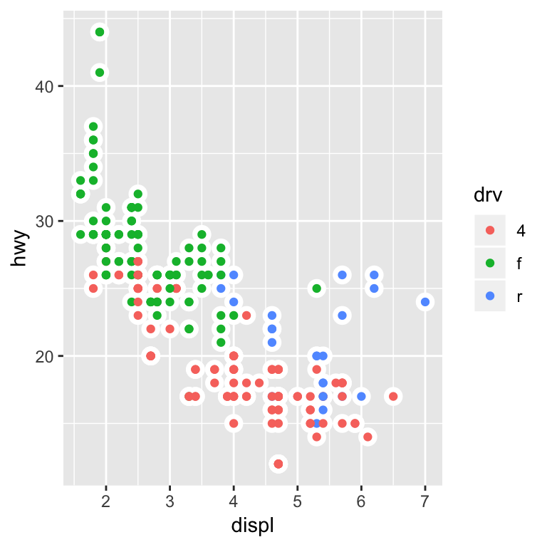

Scroll down for answer key

[output not shown]

## 3.7 Statistical transformations

Some geoms like `geom_bar()` use statistical transformations in order to create their graph. Usually you do not need to mess with these statistical transformations since every geom has a default stat and every stat has a default geom.

- bar charts, histograms, and frequency polygons bin your data and then plot bin counts, the number of points that fall in each bin.
- smoothers fit a model to your data and then plot predictions from the model.
- boxplots compute a robust summary of the distribution and then display a specially formatted box.

There are only a few cases where it makes sense to change the stat in a geom. The most common case is when you may already have the *summary transformation* complete and you still want a bar plot.

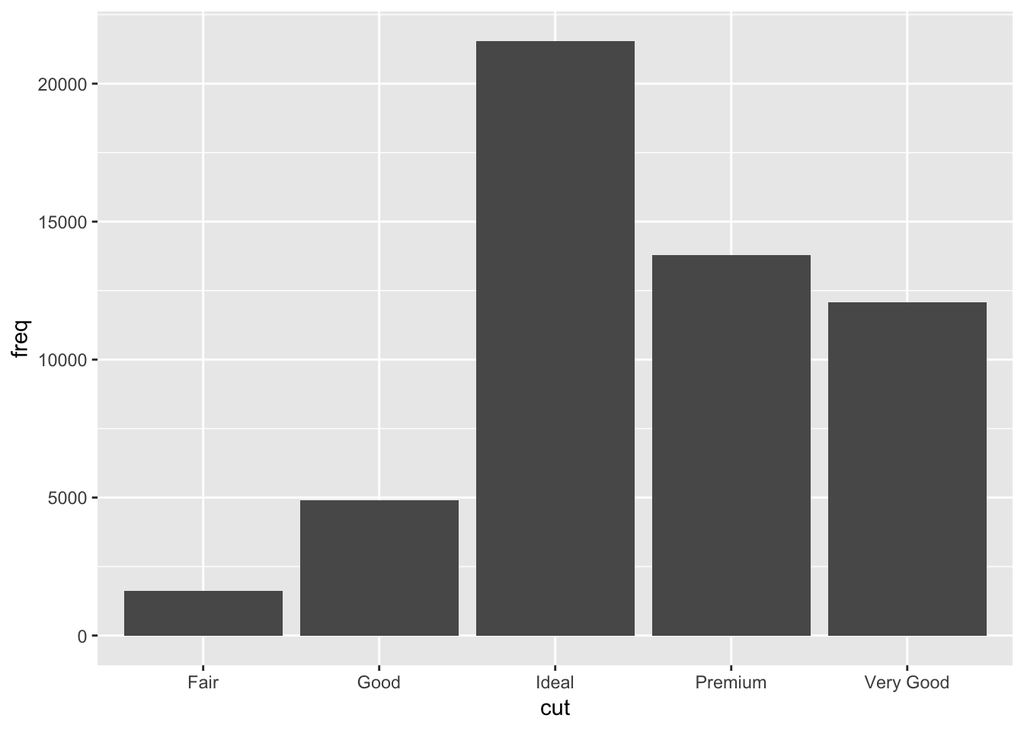

```r
demo <- tribble(
  ~cut,         ~freq,
  "Fair",       1610,
  "Good",       4906,
  "Very Good",  12082,
  "Premium",    13791,
  "Ideal",      21551
)

ggplot(data = demo) +
  geom_bar(mapping = aes(x = cut, y = freq), stat = "identity")
```

Alternatively, you could use `geom_col()` which has a different default stat.

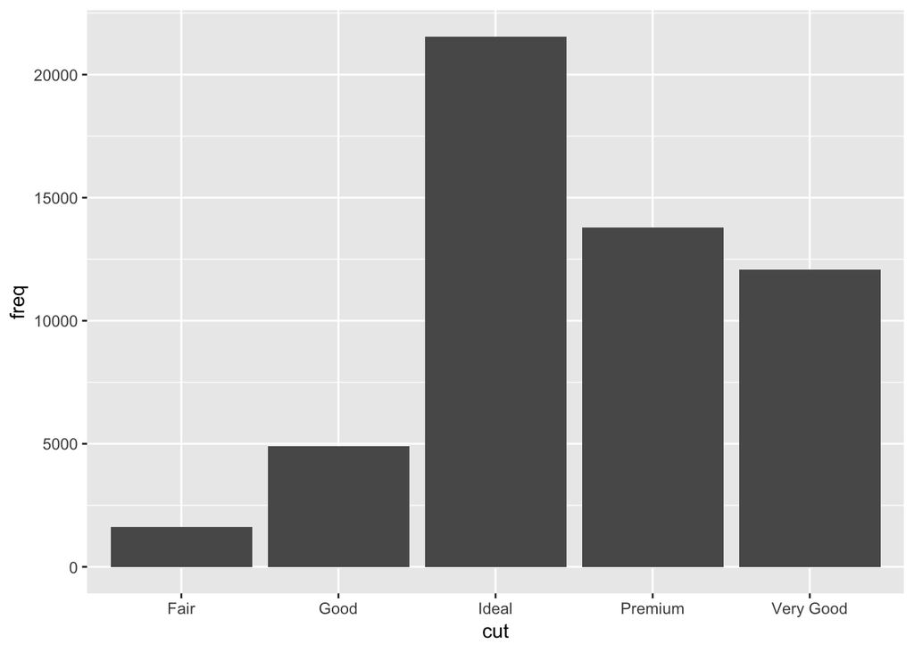

```r
ggplot(data = demo) +
  geom_col(mapping = aes(x = cut, y = freq))
```

## 3.8 Position adjustments

There’s one more piece of magic associated with bar charts. You can colour a bar chart using either the `colour` aesthetic, or, more usefully, `fill`:

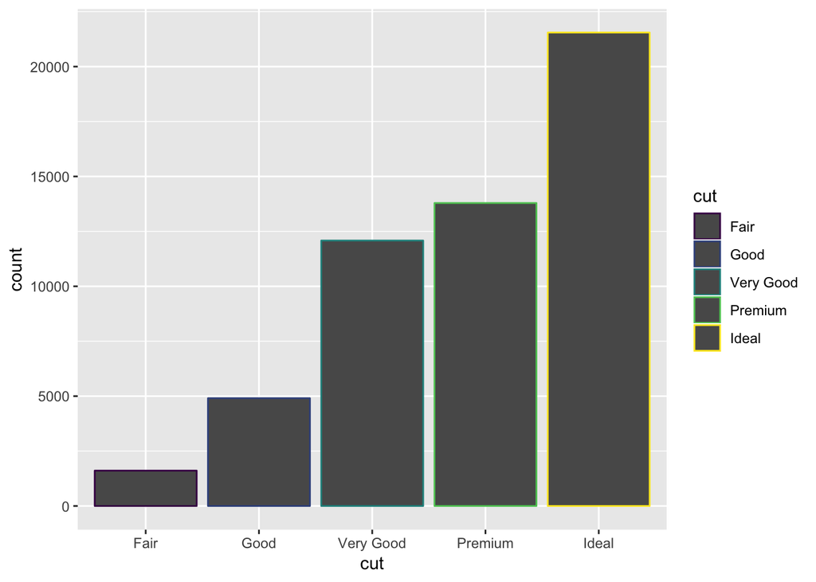

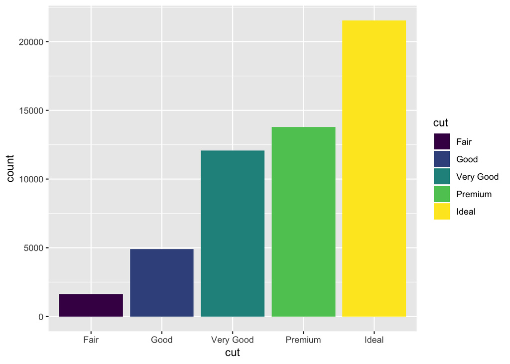

Note what happens if you map the fill aesthetic to another variable, like `clarity`: the bars are automatically stacked. Each colored rectangle represents a combination of `cut` and `clarity`.

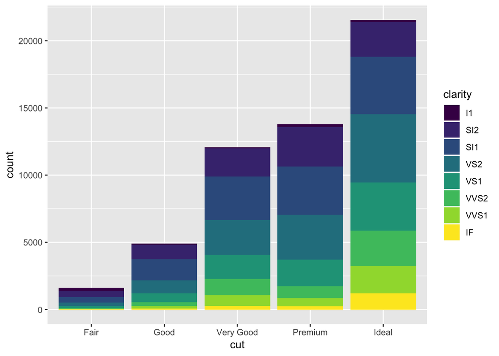

The stacking is performed automatically by the **position adjustment** specified by the `position` argument. If you don’t want a stacked bar chart, you can use one of three other options: `"identity"`, `"dodge"` or `"fill"`.

One of the more common types of position adjustments you can make is **dodge**. * `position = "dodge"` places overlapping objects directly *beside* one another. This makes it easier to compare individual values.